# Introduction to automated text analysis

Ryan Wesslen (modified)

July 27, 2016

### String manipulation with R

We will start with basic string manipulation with R.

Our first example will be a 20% sample of all Charlotte geo-located tweets between Dec 1 2015 and Feb 29 2016. We’ll save the text of these tweets as a vector called `text’

```r
tweets <- read.csv("../datasets/CharlotteTweets20Sample.csv", stringsAsFactors=F)
str(tweets)
```

```
## 'data.frame':    47274 obs. of  20 variables:
##  $ body                      : chr  "Treon to WR is a really good move by Mac, very familiar with playbook. Very good runner in open space too" "primus #vsco #vscocam #primus #primussucks #charlotte #bojanglescoliseum #livemusic… https://t.co/IqI6BIPVqn" "WOAH!!!!!!" "clear -&gt; mostly cloudytem…
##  $ postedTime                : chr  "2016-02-05T17:23:34.000Z" "2016-01-28T00:20:32.000Z" "2015-12-05T01:05:22.000Z" "2015-12-12T04:54:38.000Z" ...
##  $ favoritesCount            : int  0 0 0 0 0 0 0 0 0 0 ...
##  $ retweetCount              : int  0 0 0 0 0 0 0 0 0 0 ...
##  $ actor.id                  : num  3.86e+08 1.55e+07 9.10e+07 2.25e+08 7.73e+07 ...
##  $ displayName               : chr  "Clint Lawrence" "Josh Hofer" "hector vargas #28" "Kannapolis Weather" ...
##  $ actor.postedTime          : chr  "2011-10-06T17:28:32.000Z" "2008-07-19T16:49:51.000Z" "2009-11-19T06:03:49.000Z" "2010-12-10T03:51:40.000Z" ...
##  $ summary                   : chr  "Follower of Jesus Christ, husband, father, trains like a boss and LOVE all UF sports" "Photographer {http://www.flickr.com/corruptedlens} || Music. || n3rd. || iPhone. || Instagram {http://instagram.com/josh_hofer}"| __truncated__ "Proud Dad, Die Hard Mets fan…
##  $ friendsCount              : int  617 692 1241 2 1886 144 131 501 270 825 ...
##  $ followersCount            : int  257 1204 268 70 1923 388 1279 479 97 3813 ...
##  $ statusesCount             : int  3447 16235 22645 20292 22428 162 15196 4791 5508 27450 ...
##  $ actor.location.displayName: chr  "Fort Mill, SC" "Raleigh, NC" "Huntersville, NC" "Kannapolis, NC" ...
##  $ generator.displayName     : chr  "Twitter for iPhone" "Instagram" "Tweetbot for iΟS" "Cities" ...
##  $ geo.type                  : chr  "Polygon" "Point" "Polygon" "Point" ...
##  $ point_long                : num  NA 35.2 NA 35.5 NA ...
##  $ point_lat                 : num  NA -80.8 NA -80.6 NA ...
##  $ urls.0.expanded_url       : chr  "" "https://www.instagram.com/p/BBD_iFMJMQb/" "" "" ...
##  $ klout_score               : int  41 52 38 19 49 41 48 41 38 59 ...
##  $ hashtags                  : chr  "" "vsco,vscocam,primus,primussucks,charlotte,bojanglescoliseum,livemusic" "" "" ...
##  $ user_mention_screen_names : chr  "" "" "" "" ...
```

```r
text <- tweets$body
```

R stores the basic string in a character vector. `length` gets the number of items in the vector, while `nchar` is the number of characters in the vector.

```r
length(text)
```

```
## [1] 47274
```

```r
text[1]
```

```
## [1] "Treon to WR is a really good move by Mac, very familiar with playbook. Very good runner in open space too"
```

```r
nchar(text[1])
```

```
## [1] 105
```

Note that we can work with multiple strings at once.

```r
nchar(text[1:10])
```

```
##  [1] 105 108  10 108  34 120  67  25 118  26
```

```r
sum(nchar(text[1:10]))
```

```
## [1] 721
```

```r
max(nchar(text[1:10]))
```

```
## [1] 120
```

We can merge different strings into one using `paste`:

```r
paste(text[1], text[2], sep='--')
```

```
## [1] "Treon to WR is a really good move by Mac, very familiar with playbook. Very good runner in open space too--primus #vsco #vscocam #primus #primussucks #charlotte #bojanglescoliseum #livemusic… https://t.co/IqI6BIPVqn"
```

Charcter vectors can be compared using the `==` and `%in%` operators:

```r
tweets$geo.type[1]=="Polygon"
```

```
## [1] TRUE
```

```r
"Twitter for iPhone" %in% tweets$generator.displayName
```

```
## [1] TRUE
```

As we will see later, it is often convenient to convert all words to lowercase or uppercase.

```r
tolower(text[1])
```

```
## [1] "treon to wr is a really good move by mac, very familiar with playbook. very good runner in open space too"
```

```r
toupper(text[1])
```

```
## [1] "TREON TO WR IS A REALLY GOOD MOVE BY MAC, VERY FAMILIAR WITH PLAYBOOK. VERY GOOD RUNNER IN OPEN SPACE TOO"
```

We can grab substrings with `substr`. The first argument is the string, the second is the beginning index (starting from 1), and the third is final index.

```r
substr(text[1], 1, 2)
```

```
## [1] "Tr"
```

```r
substr(text[1], 1, 10)
```

```
## [1] "Treon to W"
```

This is useful when working with date strings as well:

```r
dates <- c("2015/01/01", "2014/12/01")
substr(dates, 1, 4) # years
```

```
## [1] "2015" "2014"
```

```r
substr(dates, 6, 7) # months
```

```
## [1] "01" "12"
```

We can split up strings by a separator using `strsplit`. If we choose space as the separator, this is in most cases equivalent to splitting into words.

```r
strsplit(text[1], " ")
```

```
## [[1]]
##  [1] "Treon"     "to"        "WR"        "is"        "a"
##  [6] "really"    "good"      "move"      "by"        "Mac,"
## [11] "very"      "familiar"  "with"      "playbook." "Very"
## [16] "good"      "runner"    "in"        "open"      "space"
## [21] "too"
```

Let’s dig into the data a little bit more. Let’s try to find Carolina Panther Tweets. To do so, let’s use the `grep` command to identify tweets with #KeepPounding. The `grep` function returns the index where the word occurs.

```r
grep('#KeepPounding', text[1:20])
```

```
## [1] 17
```

`grepl` returns `TRUE` or `FALSE`, indicating whether each element of the character vector contains that particular pattern.

```r
grepl('#KeepPounding', text[1:20])
```

```
##  [1] FALSE FALSE FALSE FALSE FALSE FALSE FALSE FALSE FALSE FALSE FALSE
## [12] FALSE FALSE FALSE FALSE FALSE  TRUE FALSE FALSE FALSE
```

Going back to the full dataset, we can use the results of `grep` to get particular rows. First, check how many tweets mention the handle “#KeepPounding”.

```r
nrow(tweets)
```

```
## [1] 47274
```

```r
grep('#KeepPounding', tweets$body[1:20])
```

```
## [1] 17
```

```r
length(grep('#KeepPounding', tweets$body))
```

```
## [1] 487
```

It is important to note that matching is case-sensitive. You can use the `ignore.case` argument to match to a lowercase version.

```r
nrow(tweets)
```

```
## [1] 47274
```

```r
length(grep('#KeepPounding', tweets$body))
```

```
## [1] 487
```

```r
length(grep('#KeepPounding', tweets$body, ignore.case = TRUE))
```

```
## [1] 738
```

### Regular expressions

Another useful tool to work with text data is called “regular expression”. You can learn more about regular expressions [here](http://www.zytrax.com/tech/web/regex.htm). Regular expressions let us develop complicated rules for both matching strings and extracting elements from them.

For example, we could look at tweets that mention more than one handle using the operator “|” (equivalent to “OR”)

```r
nrow(tweets)
```

```
## [1] 47274
```

```r
length(grep('#KeepPounding|#Panthers', tweets$body, ignore.case=TRUE))
```

```
## [1] 923
```

We can also use question marks to indicate optional characters.

```r
nrow(tweets)
```

```
## [1] 47274
```

```r
length(grep('cam?', tweets$body, ignore.case=TRUE))
```

```
## [1] 9412
```

This will match Cam, Cameron, etc.

Other common expression patterns are:

- `.` matches any character, `^` and `$` match the beginning and end of a string.
- Any character followed by `{3}`, `*`, `+` is matched exactly 3 times, 0 or more times, 1 or more times.
- `[0-9]`, `[a-zA-Z]`, `[:alnum:]` match any digit, any letter, or any digit and letter.
- Special characters such as `.`, `\`, `(` or `)` must be preceded by a backslash.
- See `?regex` for more details.

For example, how many tweets are direct replies to @Panthers? How many tweets are retweets? How many tweets mention any username?

```r
length(grep('^@Panthers', tweets$body, ignore.case=TRUE))
```

```
## [1] 56
```

```r
length(grep('^RT @', tweets$body, ignore.case=TRUE))
```

```
## [1] 3
```

```r
length(grep('@[A-Za-z0-9]+ ', tweets$body, ignore.case=TRUE))
```

```
## [1] 12630
```

Another function that we will use is `gsub`, which replaces a pattern (or a regular expression) with another string:

```r
gsub('WR', 'Wide Receiver', text[1])
```

```
## [1] "Treon to Wide Receiver is a really good move by Mac, very familiar with playbook. Very good runner in open space too"
```

To extract a pattern, and not just replace, use parentheses and choose the option `repl="\\1"`:

```r
text[7]
```

```
## [1] "@AaronCarpenter #MagconComeHere north carolina with the dolan twins"
```

```r
gsub('.*@([0-9_A-Za-z]+) .*', text[7], repl="\\1")
```

```
## [1] "AaronCarpenter"
```

You can make this a bit more complex using `gregexpr`, which will extract the location of the matches, and then `regmatches`

```r
handles <- gregexpr('@([0-9_A-Za-z]+)', text)
handles <- regmatches(text, handles)
handles <- unlist(handles)
head(sort(table(handles), decreasing=TRUE), n=25)
```

```
## handles
##      @cltairport        @Panthers        @midnight        @panthers
##              218              212              180              130
##      @EthanDolan            @ness         @hornets    @GraysonDolan
##              117               80               78               77
##    @SportsCenter       @F3theFort @realDonaldTrump     @nodabrewing
##               69               64               64               63
##    @CampersHaven   @marcuslemonis       @F3Isotope      @marielawtf
##               58               52               48               43
##          @oakley @LifeTimeFitness  @ChickenNGreens            @wcnc
##               39               38               36               36
##  @_Charlotte_NC_    @ncbeertemple   @PlanetFitness    @HarrisTeeter
##               35               35               35               34
##   @lynncjohnston
##               34
```

```r
# now with hashtags...
hashtags <- regmatches(text, gregexpr("#(\\d|\\w)+",text))
hashtags <- unlist(hashtags)
head(sort(table(hashtags), decreasing=TRUE), n=25)
```

```
## hashtags
##  #KeepPounding     #Charlotte            #NC    #realestate     #charlotte
##            487            458            443            429            256
##  #keeppounding       #traffic        #trndnl         #photo       #listing
##            234            212            205            185            159
##           #clt        #Repost       #realtor          #CIAA          #SB50
##            154            144            133            123            109
##      #Panthers      #CIAA2016       #Concord           #CLT      #panthers
##             95             89             88             86             86
##        #tshirt          #sale       #apparel            #ph #panthernation
##             85             81             80             78             74
```

```r
tweets$panthers <- grepl('#KeepPounding|#Panthers', tweets$body, ignore.case=TRUE)
table(tweets$panthers)
```

```
##
## FALSE  TRUE
## 46351   923
```

```r
panthers.tweets <- tweets[tweets$panthers==TRUE, ]
```

### Preprocessing text with quanteda

As we discussed earlier, before we can do any type of automated text analysis, we will need to go through several “preprocessing” steps before it can be passed to a statistical model. We’ll use the `quanteda` package quanteda here.

The basic unit of work for the `quanteda` package is called a `corpus`, which represents a collection of text documents with some associated metadata. Documents are the subunits of a corpus. You can use `summary` to get some information about your corpus.

```r
#install.packages("quanteda")
library(quanteda)
twcorpus <- corpus(tweets$body)
summary(twcorpus,10)
```

```
## Corpus consisting of 47274 documents, showing 10 documents.
##
##    Text Types Tokens Sentences
##   text1    22     23         2
##   text2    14     16         1
##   text3     2      7         1
##   text4    20     34         1
##   text5     9      9         1
##   text6    25     27         2
##   text7     8      8         1
##   text8     3      3         1
##   text9    18     18         1
##  text10     6      6         1
##
## Source:  /home/whitesox/Dropbox/eui-text-workshop/01-intro/* on x86_64 by whitesox
## Created: Tue Jul 26 21:19:14 2016
## Notes:
```

A useful feature of corpus objects is *keywords in context*, which returns all the appearances of a word (or combination of words) in its immediate context.

```r
head(kwic(twcorpus, "hornets", window=5),10)
```

```
##                                                        contextPre keyword
##  [text223, 27]                              BS posturing w/ the [ hornets
##  [text351, 11]            #Hornets#BuzzCity#Clippers@ Charlotte [ Hornets
##   [text789, 8]                                  awesome game!!! [ HORNETS
##  [text789, 12]                                  ! HORNETS WIN!! [ HORNETS
##  [text789, 16]                                  ! HORNETS WIN!! [ HORNETS
##   [text848, 4]                #coxsportsbroadcasting@ Charlotte [ Hornets
##  [text1514, 1]                                                  [ Hornets
## [text2056, 11]                         ! Team#Lakers@ Charlotte [ Hornets
##  [text2757, 8]                       Live!#gohornets@ Charlotte [ Hornets
##  [text3290, 4]                                  NEXT WEDNESDAY, [ HORNETS
##                                           contextPost
##  [text223, 27] ] when they left.
##  [text351, 11] ] Arena https://
##   [text789, 8] ] WIN!! HORNETS WIN
##  [text789, 12] ] WIN!! HORNETS WIN
##  [text789, 16] ] WIN!!#charlottehornets#hornets
##   [text848, 4] ] Arena https://
##  [text1514, 1] ] ' Michael Kidd- Gilchrist
## [text2056, 11] ] Arena https://
##  [text2757, 8] ] Arena https://
##  [text3290, 4] ] vs. CAVSposhmixer#1stWednesdaysFeb 3
```

```r
head(kwic(twcorpus, "beer", window=5),10)
```

```
##                                                 contextPre keyword
##   [text909, 6]                     I wonder what kind of [    beer
## [text1007, 18]                                    ba...( [    Beer
##  [text1895, 1]                                           [    Beer
##  [text1966, 4]                              I don't like [    beer
##  [text2049, 4]                               I'm at VBGB [    Beer
##  [text2276, 1]                                           [    Beer
##  [text3382, 4]                               I'm at VBGB [    Beer
##  [text3696, 4]                          Good Local Craft [    Beer
##  [text4051, 2]                                      Good [    beer
##  [text4148, 6]                 Drinking a Best Damn Root [    Beer
##                                              contextPost
##   [text909, 6] ] Peyton is gonna drink tonight
## [text1007, 18] ] Camp Tropical IPA( 2016
##  [text1895, 1] ] brewing on a Saturday morning
##  [text1966, 4] ] but I found an even
##  [text2049, 4] ] Hall& amp; Garden
##  [text2276, 1] ] Special! Enjoy our delicious
##  [text3382, 4] ] Hall& amp; Garden
##  [text3696, 4] ] , and football. Panthers
##  [text4051, 2] ] . I like this.
##  [text4148, 6] ] by@bestdamnbrewing@ Spectrum South
```

```r
head(kwic(twcorpus, "amy", window=5),10)
```

```
##                                             contextPre keyword
##   [text1269, 8]          Time Warner Cable Arena for [     Amy
##  [text1843, 17]                     30 Hatha Yoga W/ [     Amy
##  [text1843, 24]                      : 30 Vinyasa w/ [     Amy
##  [text11426, 3]                              #BRAVE@ [     Amy
## [text15167, 11]               to laugh out loud with [     Amy
## [text16001, 10]                   me I remind her of [     Amy
## [text16001, 18]       that's exciting because I LOVE [     AMY
## [text19254, 13]                     30 Hatha Yoga w/ [     Amy
##  [text22200, 2]                              Amazing [     Amy
## [text23339, 10]                 45 Gentle Stretch w/ [     Amy
##                                            contextPost
##   [text1269, 8] ] Schumer in Charlotte, NC
##  [text1843, 17] ] S10: 30 Vinyasa w
##  [text1843, 24] ] S2: 00… https
##  [text11426, 3] ] Schumer Timewarner cable arena https
## [text15167, 11] ] Schumer at Time Warner in
## [text16001, 10] ] Schumer and that's exciting because
## [text16001, 18] ]
## [text19254, 13] ] S10: 30 Vinyasa w
##  [text22200, 2] ]
## [text23339, 10] ] P7: 30 Twin Hearts
```

We can then convert a corpus into a document-feature matrix using the `dfm` function.

```r
twdfm <- dfm(twcorpus)
```

```
## Creating a dfm from a corpus ...
##    ... lowercasing
##    ... tokenizing
##    ... indexing documents: 47,274 documents
##    ... indexing features: 74,367 feature types
##    ... created a 47274 x 74368 sparse dfm
##    ... complete.
## Elapsed time: 2.511 seconds.
```

`dfm` has many useful options. Let’s actually use it to stem the text, extract n-grams, remove punctuation, keep Twitter features…

```r
?dfm
twdfm <- dfm(twcorpus, toLower=TRUE, removeNumbers=TRUE, removePunct=TRUE,
             removeTwitter=FALSE, stem=TRUE, ngrams=c(1,3))
```

```
## Creating a dfm from a corpus ...
##    ... lowercasing
##    ... tokenizing
##    ... indexing documents: 47,274 documents
##    ... indexing features: 415,230 feature types
##    ... stemming features (English), trimmed 7716 feature variants
##    ... created a 47274 x 407515 sparse dfm
##    ... complete.
## Elapsed time: 16.794 seconds.
```

You can explore what each of these options do by using the `tokenize` function:

```r
tokenize(tweets$body[1])
```

```
## tokenizedText object from 1 document.
## Component 1 :
##  [1] "Treon"    "to"       "WR"       "is"       "a"        "really"
##  [7] "good"     "move"     "by"       "Mac"      ","        "very"
## [13] "familiar" "with"     "playbook" "."        "Very"     "good"
## [19] "runner"   "in"       "open"     "space"    "too"
```

```r
tokenize(tweets$body[1], verbose=TRUE)
```

```
## Starting tokenization...
##   ...preserving Twitter characters (#, @)...total elapsed: 0 seconds.
##   ...tokenizing texts
##   ...removing separators....total elapsed:  0 seconds.
##   ...replacing Twitter characters (#, @)...total elapsed: 0 seconds.
##   ...replacing names...total elapsed:  0 seconds.
## Finished tokenizing and cleaning 1 texts.
```

```
## tokenizedText object from 1 document.
## Component 1 :
##  [1] "Treon"    "to"       "WR"       "is"       "a"        "really"
##  [7] "good"     "move"     "by"       "Mac"      ","        "very"
## [13] "familiar" "with"     "playbook" "."        "Very"     "good"
## [19] "runner"   "in"       "open"     "space"    "too"
```

```r
tokenize(tweets$body[1], removeNumbers=TRUE, removePunct=TRUE)
```

```
## tokenizedText object from 1 document.
## Component 1 :
##  [1] "Treon"    "to"       "WR"       "is"       "a"        "really"
##  [7] "good"     "move"     "by"       "Mac"      "very"     "familiar"
## [13] "with"     "playbook" "Very"     "good"     "runner"   "in"
## [19] "open"     "space"    "too"
```

```r
tokenize(tweets$body[1], removeNumbers=FALSE, removePunct=TRUE)
```

```
## tokenizedText object from 1 document.
## Component 1 :
##  [1] "Treon"    "to"       "WR"       "is"       "a"        "really"
##  [7] "good"     "move"     "by"       "Mac"      "very"     "familiar"
## [13] "with"     "playbook" "Very"     "good"     "runner"   "in"
## [19] "open"     "space"    "too"
```

```r
tokenize(tweets$body[1], removeNumbers=FALSE, removePunct=FALSE)
```

```
## tokenizedText object from 1 document.
## Component 1 :
##  [1] "Treon"    "to"       "WR"       "is"       "a"        "really"
##  [7] "good"     "move"     "by"       "Mac"      ","        "very"
## [13] "familiar" "with"     "playbook" "."        "Very"     "good"
## [19] "runner"   "in"       "open"     "space"    "too"
```

```r
tokenize(tweets$body[1], removeNumbers=FALSE, removePunct=FALSE, removeTwitter=FALSE)
```

```
## tokenizedText object from 1 document.
## Component 1 :
##  [1] "Treon"    "to"       "WR"       "is"       "a"        "really"
##  [7] "good"     "move"     "by"       "Mac"      ","        "very"
## [13] "familiar" "with"     "playbook" "."        "Very"     "good"
## [19] "runner"   "in"       "open"     "space"    "too"
```

```r
tokenize(tweets$body[1], removeNumbers=FALSE, removePunct=FALSE, removeTwitter=TRUE)
```

```
## tokenizedText object from 1 document.
## Component 1 :
##  [1] "Treon"    "to"       "WR"       "is"       "a"        "really"
##  [7] "good"     "move"     "by"       "Mac"      ","        "very"
## [13] "familiar" "with"     "playbook" "."        "Very"     "good"
## [19] "runner"   "in"       "open"     "space"    "too"
```

```r
tokenize(tweets$body[1], removeNumbers=FALSE, removePunct=FALSE, removeSeparators=FALSE)
```

```
## tokenizedText object from 1 document.
## Component 1 :
##  [1] "Treon"    " "        "to"       " "        "WR"       " "
##  [7] "is"       " "        "a"        " "        "really"   " "
## [13] "good"     " "        "move"     " "        "by"       " "
## [19] "Mac"      ","        " "        "very"     " "        "familiar"
## [25] " "        "with"     " "        "playbook" "."        " "
## [31] "Very"     " "        "good"     " "        "runner"   " "
## [37] "in"       " "        "open"     " "        "space"    " "
## [43] "too"
```

```r
tokenize(tweets$body[1], stem=FALSE)
```

```
## tokenizedText object from 1 document.
## Component 1 :
##  [1] "Treon"    "to"       "WR"       "is"       "a"        "really"
##  [7] "good"     "move"     "by"       "Mac"      ","        "very"
## [13] "familiar" "with"     "playbook" "."        "Very"     "good"
## [19] "runner"   "in"       "open"     "space"    "too"
```

Stemming relies on the `SnowballC` package’s implementation of the Porter stemmer:

```r
tokenize(tweets$body[1])
```

```
## tokenizedText object from 1 document.
## Component 1 :
##  [1] "Treon"    "to"       "WR"       "is"       "a"        "really"
##  [7] "good"     "move"     "by"       "Mac"      ","        "very"
## [13] "familiar" "with"     "playbook" "."        "Very"     "good"
## [19] "runner"   "in"       "open"     "space"    "too"
```

```r
wordstem(tokenize(tweets$body[1]))
```

```
## tokenizedText object from 1 document.
## Component 1 :
##  [1] "Treon"    "to"       "WR"       "i"        "a"        "realli"
##  [7] "good"     "move"     "by"       "Mac"      ","        "veri"
## [13] "familiar" "with"     "playbook" "."        "Veri"     "good"
## [19] "runner"   "in"       "open"     "space"    "too"
```

In a large corpus like this, many features often only appear in one or two documents. In some case it’s a good idea to remove those features, to speed up the analysis or because they’re not relevant. We can `trim` the dfm:

```r
twdfm <- trim(twdfm, minDoc=3)
```

```
## Removing features occurring in fewer than 3 documents: 383316
```

It’s often a good idea to take a look at a wordcloud of the most frequent features to see if there’s anything weird.

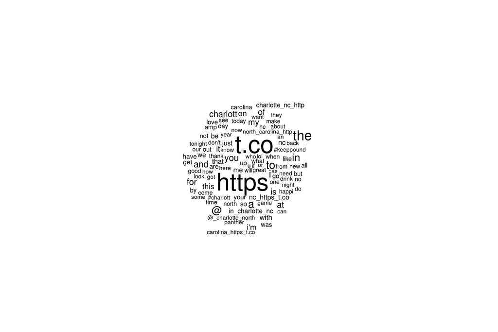

```r
plot(twdfm, rot.per=0, scale=c(3.5, .75), max.words=100)
```

What is going on? We probably want to remove words and symbols which are not of interest to our data, such as http here. This class of words which is not relevant are called stopwords. These are words which are common connectors in a given language (e.g. “a”, “the”, “is”). We can also see the list using `topFeatures`

```r
topfeatures(twdfm, 25)
```

```
##     t.co    https      the       to        a        i       in        @
##    27861    27819    12324     8681     8196     7678     7596     7480
##      and      you charlott       at      for       of       is       my
##     5625     5568     5040     5019     4991     4893     4504     4480
##       it       on     this      i'm     with       nc     that       me
##     4266     3793     3504     3237     2955     2833     2785     2530
##       be
##     2341
```

We can remove the stopwords when we create the `dfm` object:

```r
twdfm <- dfm(twcorpus, ignoredFeatures=c(
  stopwords("english"), "t.co", "https", "rt", "amp", "http", "t.c", "can", "u"), ngrams=c(1,3))
```

```
## Creating a dfm from a corpus ...
##    ... lowercasing
##    ... tokenizing
##    ... indexing documents: 47,274 documents
##    ... indexing features: 415,230 feature types
##    ... removed 269,437 features, from 182 supplied (glob) feature types
##    ... created a 47274 x 145794 sparse dfm
##    ... complete.
## Elapsed time: 11.107 seconds.
```

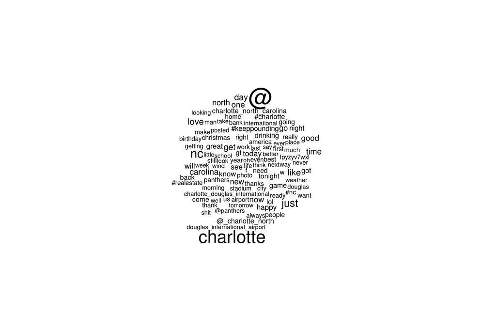

```r
plot(twdfm, rot.per=0, scale=c(3.5, .75), max.words=100)
```

One nice feature of quanteda is that we can easily add metadata to the corpus object.

```r
docvars(twcorpus) <- data.frame(geo.type=tweets$geo.type, device=tweets$generator.displayName)
summary(twcorpus,10)
```

```
## Corpus consisting of 47274 documents, showing 10 documents.
##
##    Text Types Tokens Sentences geo.type              device
##   text1    22     23         2  Polygon  Twitter for iPhone
##   text2    14     16         1    Point           Instagram
##   text3     2      7         1  Polygon    Tweetbot for iΟS
##   text4    20     34         1    Point              Cities
##   text5     9      9         1  Polygon  Twitter for iPhone
##   text6    25     27         2    Point           Instagram
##   text7     8      8         1  Polygon  Twitter Web Client
##   text8     3      3         1  Polygon  Twitter for iPhone
##   text9    18     18         1  Polygon Twitter for Android
##  text10     6      6         1  Polygon  Twitter for iPhone
##
## Source:  /home/whitesox/Dropbox/eui-text-workshop/01-intro/* on x86_64 by whitesox
## Created: Tue Jul 26 21:19:14 2016
## Notes:
```

We can then use this metadata to subset the dataset:

```r
point.tweets <- subset(twcorpus, geo.type=="Point")
```

And then extract the text:

```r
mytexts <- texts(point.tweets)
```

We’ll come back later to this dataset.

### Importing text with quanteda

There are different ways to read text into `R` and create a `corpus` object with `quanteda`. We have already seen the most common way, importing the text from a csv file and then adding the metadata, but `quanteda` has a built-in function to help with this:

```r
tweets <- textfile(file='../datasets/CharlotteTweets20Sample.csv', textField = 'body')
twcorpus <- corpus(tweets)
```

This function will also work with text in multiple files. To do this, we use the textfile command, and use the ‘glob’ operator ’*’ to indicate that we want to load multiple files:

```r
myCorpus <- corpus(textfile(file='../datasets/inaugural/*.txt'))
```